# Tensors - motivation

### **NOTES ON STATISTICS, PROBABILITY and MATHEMATICS**

### Motivation for Tensors:

From [this post](https://jeremykun.com/2014/01/17/how-to-conquer-tensorphobia/):

Examples of multilinear maps:

1. If $V$ is an inner product space over $\mathbb{R},$ then the inner product is bilinear.
2. Matrix multiplication as an operation.
3. The determinant of a matrix is a multilinear map if we view the columns of the matrix as vector arguments.
4. The cross product of vectors in $\mathbb{R}^3$ is bilinear.

#### Comparison of multilinear maps to linear maps:

Given two vector spaces $V$ and $W$, the direct sum is the Cartesian product
$$V \times W$$
inbued with a linear algebraic structure. We have the set $X\oplus W =\{(v_i,w_i)\}$ of ordered pairs, and we define

Addition:

$$(v_1,w_1) + (v_2,w_2)=(v_1 + v_2, w_1 +
w_2)$$
Scalar multiplication:

$$\lambda(v_i,w_i)=(\lambda\,v_i\quad,\quad\lambda
\,w_i)$$

Instead, the **TENSOR PRODUCT SPACE (TPS)** $V\otimes W$ also departs from the set of Cartesian products of individual vector spaces, renaming the pais $(v_i,w_i)$ to $v_i\otimes w_i.$ BUT in the TPS,

addition is **only** defined when one of the two components is identical:

$$(v_1\;\otimes\;\color{red}{ w_1}) +
(v_2\;\otimes\;\color{red}{w_1}) = (v_1 +
v_2\quad\otimes\quad\color{red}{w_1})$$

and scalar multiplication is defined to be the same applied to any component:

$$\lambda\,(v_i \otimes w_i) =
\lambda\,v_i \otimes w_i=v_i \otimes \lambda w_i$$

In general, multilinearity is characterized by

$$T\left(v_1 , v_2 , v_3 , v_i + v_j ,
\cdots, v_n\right)
= T\left(v_1 , v_2 , v_3 , v_i, \cdots , v_n\right)+T\left(v_1 , v_2 ,
v_3 , v_j, \cdots , v_n\right)$$

and

$$T\left(v_1 , v_2 , k\,v_3 , \cdots ,
v_n\right)=k\,T\left(v_1 , v_2 , v_3 , \cdots , v_n\right)$$

with $T$ standing for linear transformation.

## Tensor product of two copies of $\mathbb R:$

This is the TPS $\mathbb R \otimes \mathbb R,$ comprising vectors such as $3\otimes 5.$

$$3\otimes 5 \quad+\quad 1\otimes
(-5)\quad=\quad 3\otimes \color{red}5 \quad + \quad (-1)\otimes
\color{red} 5 \quad =\quad 2 \otimes \color{red}5$$

also

$$6\otimes 1 \quad+\quad
3\pi\otimes\pi\quad = \quad \underbrace{\color{red}3\otimes 2}_{2\times
3\otimes1=3\otimes 2\times 1}\quad + \quad \color{red}3\otimes
\pi^2\quad=\quad \color{red}3 \otimes(2 +\pi^2)$$

## Dot products:

$$\text{dot}\left( \begin{bmatrix}1\\2\\3
\end{bmatrix} , \begin{bmatrix} 1\\0\\1\end{bmatrix}\right)=1\times 1 +
2\times 0+3\times 1 =4$$

$$\begin{align}
\text{dot}\left(5 \begin{bmatrix}1\\2\\3 \end{bmatrix} , \begin{bmatrix}
1\\0\\1\end{bmatrix}\right)&=5\;\text{dot}\left(
\begin{bmatrix}1\\2\\3 \end{bmatrix} , \begin{bmatrix}
1\\0\\1\end{bmatrix}\right)\\[2ex]
&=5\times1\times 1 + 5\times 2\times 0+5\times3\times 1\\[2ex]
&=5\,\left(1\times 1 + 2\times 0+3\times 1 \right)=20
\end{align}$$

and

$$\begin{align}
\text{dot}\left( \begin{bmatrix}1\\2\\3 \end{bmatrix} , \begin{bmatrix}
1\\0\\1\end{bmatrix}+\begin{bmatrix}
2\\1\\1\end{bmatrix}\right)&=\text{dot}\left( \begin{bmatrix}1\\2\\3
\end{bmatrix} , \begin{bmatrix}
1\\0\\1\end{bmatrix}\right)+\text{dot}\left( \begin{bmatrix}1\\2\\3
\end{bmatrix} , \begin{bmatrix} 2\\1\\1\end{bmatrix}\right)\\[2ex]
11&=4+7
\end{align}$$

## Matrices:

Considering matrices as vectors, and $m(\cdot)$ representing the matrix product operator, i.e. given matrices $A$ and $B,$ the product $m(A,B) = AB,$

$$\begin{align}
m(A +B\;,\;C+D)\quad&\neq\quad m(A,C) \quad+\quad m(B,D)\\[2ex]
(A+B)(C+D)\quad &\neq \quad AC + BD
\end{align}$$

but if we fix the second coordinate,

$$m(A +C\;,\; B) \quad=
\quad(A+C)B\quad=\quad AB + CB \quad =\quad m(A,B) \quad+\quad
m(C,B)$$

Here is an obvious numeric example:

$$\left( \begin{bmatrix} 6&2\\0&-1
\end{bmatrix} + \begin{bmatrix} 4&2\\0&-5
\end{bmatrix}\right)\,\color{red}{\begin{bmatrix} 1&2\\3&-1
\end{bmatrix}}=\left( \begin{bmatrix} 6&2\\0&-1 \end{bmatrix} \,
\color{red}{\begin{bmatrix} 1&2\\3&-1
\end{bmatrix}}\right)+\left( \begin{bmatrix} 4&2\\0&-5
\end{bmatrix} \, \color{red}{\begin{bmatrix} 1&2\\3&-1
\end{bmatrix}}\right)$$

```r
A = matrix(c(6,0,2,-1),2,2)
B = matrix(c(4,0,2,-5),2,2)
C = matrix(c(1,3,2,-1),2,2)
D = matrix(c(2,0,-2,5),2,2)

all.equal((A + C) %*% B        ,  (A %*% B) + (C %*% B))
```

```
## [1] TRUE
```

but

$$\left( \begin{bmatrix} 6&2\\0&-1
\end{bmatrix} + \begin{bmatrix} 4&2\\0&-5
\end{bmatrix}\right)\,\left(\begin{bmatrix} 1&2\\3&-1
\end{bmatrix}+\begin{bmatrix}2&-2\\0&5\end{bmatrix}\right)
\neq
\left( \begin{bmatrix} 6&2\\0&-1 \end{bmatrix} \,\begin{bmatrix}
1&2\\3&-1 \end{bmatrix}\right)+\left( \begin{bmatrix}
4&2\\0&-5 \end{bmatrix} \, \begin{bmatrix} 2&-2\\0&5
\end{bmatrix}\right)$$

```r
all.equal((A + B) %*% (C + D)  ,  (A %*% C) + (B %*% D))
```

```
## [1] "Mean relative difference: 0.5394737"
```

so $m(\cdot)$ as defined is more akin to a multilinear map than a linear map from a vector space $V$ to a vector space $W$: $\varphi: V \to W$ as in a change of coordinates, where

$$\begin{bmatrix}a_{11}& a_{12} &
a_{13}\\
a_{21}& a_{22} & a_{23}\\
a_{31}& a_{32} & a_{33}\\
a_{41}& a_{42} & a_{43}
\end{bmatrix}
\begin{bmatrix}v_1^1\\v_1^2\\v_1^3
\end{bmatrix}=\begin{bmatrix}w_1^1\\w_1^2\\w_1^3\\w_1^4\end{bmatrix}$$

in which case

$$\varphi(v_1,v_2)+\varphi(v_3, v_4) =
\left(\varphi(v_1 + v_3),\varphi(v_2+v_4)\right)$$

Here is the idea encoded:

```r
set.seed(0)
m = matrix(rnorm(12),4,3)
v1 = 1:3
v2 = 3:5
v3 = 5:7
v4 = 7:9
varphi_v1 = m %*% v1
varphi_v2 = m %*% v2
varphi_v3 = m %*% v3
varphi_v4 = m %*% v4

sum_after_lin_map = varphi_v1 + varphi_v3
lin_map_after_sum = varphi_v1_plus_v3 = m %*% (v1 + v3)
all.equal(sum_after_lin_map, lin_map_after_sum)
```

```
## [1] TRUE
```

```r
sum_after_lin_map_2 = varphi_v2 + varphi_v4
lin_map_after_sum_2 = varphi_v2_plus_v4 = m %*% (v2 + v4)
all.equal(sum_after_lin_map_2, lin_map_after_sum_2)
```

```
## [1] TRUE
```

Same goes for scalar multiplication:

$$m(\alpha A,B) = \alpha AB = A(\alpha B)
=m(A,\alpha B)= \alpha m (A,B)$$

```r
alpha = sample(2:10,1)
all.equal((alpha * A) %*% B, alpha * (A %*% B), A%*%(alpha * B), A %*% (alpha * B), alpha * (A%*%B))
```

```
## [1] TRUE
```

whereas in the case of vectors:

$$\lambda
\,\varphi(v_1,v_2)+\lambda\;\varphi(v_3, v_4) =
\left(\lambda\;\varphi(v_1 +
v_3)\quad,\quad\lambda\;\varphi(v_2+v_4)\right)$$

```r
lambda = alpha
lambda_times_sum_after_lin_map = lambda * varphi_v1 + lambda * varphi_v3
lambda_times_lin_map_after_sum = varphi_v1_plus_v3 = lambda * ( m %*% (v1 + v3) )
all.equal(lambda_times_sum_after_lin_map, lambda_times_lin_map_after_sum)
```

```
## [1] TRUE
```

CONCLUSION:

Pairings of matrices (simbolized by $(\cdot, \cdot)$) above, but clearly hinting at $(\cdot \otimes \cdot)$ don’t show a linear behavior when subjected to a function such as matrix multiplication. So, although we can pair (Cartesian product) matrix to create a vector space, it will not show the same linear properties as with a typical “arrow” vector space. The properties for a vector space formed by pairing matrices will behave like a TPS with bilinear, or more generally, multilinear features.

## Determinants:

$$\det\begin{bmatrix} \vert& \vert
& \vert\\ v_1 & v_2 & v_3\\ \vert & \vert &
\vert \end{bmatrix}+\det\begin{bmatrix} \vert& \vert & \vert\\
v_1 & v_2 & v_4\\ \vert & \vert & \vert \end{bmatrix}
= \det\begin{bmatrix} \vert& \vert & \vert\\ v_1 & v_2 &
(v_3 + v_4)\\ \vert & \vert & \vert \end{bmatrix}$$

```r
v1 = 1:3; v2 = 3:5; v3 = 5:7; v4 = c(0,1,-2)
mat.1 = cbind(v1,v2,v3); mat.2 = cbind(v1,v2,v4)
all.equal(det(mat.1) + det(mat.2) ,  det(cbind(v1, v2, v3 + v4)))
```

```
## [1] TRUE
```

and

$$k \;\det\begin{bmatrix} \vert& \vert
& \vert\\ v_1 & v_2 & v_3\\ \vert & \vert &
\vert \end{bmatrix}=\det\begin{bmatrix} \vert& \vert & \vert\\
v_1 &k\; v_2 & v_3\\ \vert & \vert &
\vert \end{bmatrix}$$

```r
all.equal(5 * det(mat.1), det(cbind(v1, 5 * v2, v3)))
```

```
## [1] TRUE
```

Consider the determinant of a matrix as an alternating (changing signs) multilinear operator. Matrices have to be square to have a determinant, and in the case of a matrix in $\mathbb R^3$ formed by two linearly independent column vectors, we’ll need to add an additional vector. For example:

$\vec v = \begin{bmatrix}1\\2\\3\end{bmatrix}$ and $\vec w = \begin{bmatrix}-1\\7\\-2 \end{bmatrix}$ can form a matrix with an element of the standard basis added in the third column resulting in the determinant:

$$\det\begin{bmatrix} 1 &-1
&1\\\bbox[5px,border:2px solid red]{2}&\bbox[5px,border:2px
solid red]7&0\\\bbox[5px,border:2px solid
yellow]3&\bbox[5px,border:2px solid
yellow]{-2}&0\end{bmatrix}=\begin{vmatrix}2&7\\3&-2\end{vmatrix}=-25$$
while using $\vec e_2$ in the last column would result in:

$$\det\begin{bmatrix} \bbox[5px,border:2px
solid red]1 &\bbox[5px,border:2px solid red]{-1}
&0\\2&7&1\\\bbox[5px,border:2px solid
yellow]3&\bbox[5px,border:2px solid
yellow]{-2}&0\end{bmatrix}=\begin{vmatrix}1&-1\\3&-2\end{vmatrix}=-1$$

We are really doing determinants of $2 \times 2$ determinants by choosing rows of the matrix

$$\begin{bmatrix}\vert & \vert \\ \vec
v & \vec w \\\vert&\vert \end{bmatrix}$$

in this case we are choosing $3 \choose 2$ combinations of rows.

Notationally, we could select these rows using the differential form $\text{d}x_i$ mapping or function, which selects the $i$-th entry of a vector, but extending it to a row by using two indices. So, in general $\phi_i = \text{d}x_i$ applied to the vector $\vec v$ would produce $\text{d}x_i(\vec v)=v_i =\vec v\cdot \vec e_i.$ We could use the notation $\text{d}(\vec x_{12}(\vec v, \vec w)$ to indicate the determinant of the first and second rows in that order.

If the vectors $\vec v$ and $\vec w$ determine a parallelogram, the result of the function described would correspond to the signed projection of this parallelogram on combinations of $(x,y,z)$ coordinate planes:

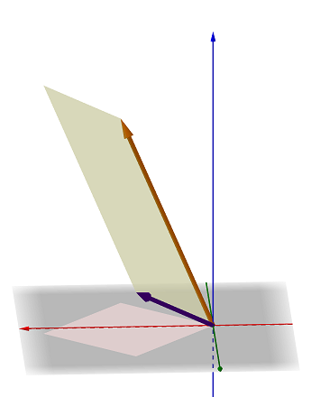

$\Lambda^k\left(\mathbb R^n \right)^*$ could denote the vector space of all alternating multilinear functions of $k$ vectors in $\mathbb R^n:$

$$\underbrace{\mathbb R^n \times \cdots
\times \mathbb R^n}_k \to \mathbb R.$$

In this case $n = 3,$ and $k =2.$

If $k=1,$ we end up with $\left( R^n\right)^*:$ The collection of linear maps $\mathbb R^n \to \mathbb R.$ These are of the form

$$T(\vec x) = \vec a \cdot \vec
x$$

for some $\vec a \in \mathbb R^n.$

This vector space (the dual) has basis

$$\{\;\phi_1(\vec x) = \vec x \cdot \vec
e_1\quad,\quad \phi_2(\vec x) = \vec x \cdot \vec e_2 \quad,\quad
\dots\quad,\quad \phi_n(\vec x) = \vec x \cdot \vec
e_n\;\}.$$

If $k = n,$ we end up with the determinant of a $3\times 3$ matrix. This is a $1$-dim vector space with basis $\text{d}\vec x_{123\dots n} = \text{determinant}.$

We can define $\text{d}\vec x_{i_1,i_2,\dots,i_k}\left( \vec v_1, \vec v_2, \dots, \vec v_k \right)=\begin{vmatrix}v_{1_{i_1}} & v_{2_{i_1}} & \cdots & v_{k_{i_1}} \\ v_{2_{i_2}} & v_{2_{i_2}}&\cdots & v_{k_{i_2}}\\ &\vdots&\\ v_{1_{i_k}} & v_{2_{i_k}}& \cdots & v_{k_{i_k}}\end{vmatrix}.$

For $\Lambda^2\left( \mathbb R^3\right)^*$ we can get the maps $\text{d}\vec v_{ij}$ with $i<j,$ i.e. increasing indices: $\text{d}\vec v_{12}, \text{d}\vec v_{13}, \text{d}\vec v_{23}$ - given that $\text{d}\vec v_{12}=- \text{d}\vec v_{21}.$ In general we have $n \choose k.$

[Home Page](http://rinterested.github.io/statistics/index.html)

**NOTE: These are tentative notes on different topics for personal use - expect mistakes and misunderstandings.**